# Activity: Introduction to R and Graphics

Engineering Statistics I (MA223)

This activity is for educational purposes only. That is, you will not be submitting answers to any of the questions in this activity. It is meant to make some of the more abstract concepts in the course a bit more concrete. Being able to address the questions in this activity will help you in preparing for other assessments in the course.

Engineers and scientists have long dependend on data and statistical analyses in order to advance their disciplines. Modern data analysis requires the use of computational software. While their are many choices for statistical software, they can largely be divided into two categories: point-and-click interfaces and computing languages. The former tends to have a spreadsheet to store data and uses a menu system to run standard analyses. The latter tends to require writing scripts in a text editor and uses a series of commands to run analyses. We will be using R (along with RStudio as its interface), which belongs to the latter group.

This is **not** a programming course; so, while we are using a computing language to perform analyses in this class, we do so with a goal of minimizing programming. Instead of focusing on programming concepts, we will have a set of basic functions we use to perform the analysis. The computing language should support the concepts taught in the course, not interfere with them. One of the primary benefits of using a computing language is *reproducibility* — the ability to record exactly what steps were taken in conducting an analysis. This is becoming more of a a standard in both engineering and scientific disciplines (think of a lab notebook for your analysis).

In this activity, we will provide an introduction to the computing language for the course and how to use it to construct graphical summaries of a single variable.

The RStudio software does not exist on your machine. It lives on a server in EIT; you are accessing it through the web interface. As a result, you have to transfer key files (like assignment templates or datasets) to the server. This is done by clicking on the “Files” tab in the lower-right pane of RStudio (with various folders in it). Click into the folder in which you would like to place the file; then, click the “Upload” button. A window browser will pop up, allowing you to search your machine to find the file downloaded from Moodle (generally located in your “Downloads” folder).

As an example, you should upload the “LabA-Graphics-Student.Rmd” file which was provided to you along with this HTML page. I suggest placing it in the “Class Demos” folder. After uploading it, when you click on the file within RStudio, you will see a text file open. This file is known as an RMarkdown file. These files have three components:

- Markdown Text: this is the plain text and special attributes that allow you to format the output. You will not need to do much with this other than type basic text; but, a cheatsheet of options is available by looking under the menu under “Help > Cheatsheets > R Markdown Cheatsheet”.
- R Code Chunks: placed within the triple tick marks ```, these blocks define R code which is executed and then “knit” (or compiled) into the final document. This allows you to reproduce an entire report and update the analysis in a single step.
- Special “instructor” blocks (only in some assignments) which highlight special text in the output and denote questions or prompts to you the student.

Clicking the “Knit” button found at the top of the script panel (below the main menu system) will take your code and text and create a Word document. This final Word document is what is submitted for an assignment. You can “Export”/“Download” the file to your local machine and then upload it to Moodle.

Now, let’s get some background on the data we will be working with in this activity.

## Background

The first dataset we will be working with is entitled `starwars`. This dataset contains characteristics on each of the 87 characters which appeared in the first six Star Wars movies. The dataset contains the following variables:

- `name`: the name of the character
- `height`: height of the character (cm)
- `mass`: mass of the character (kg)
- `hair_color`: hair color, if applicable
- `skin_color`: skin color
- `eye_color`: eye color
- `birth_year`: year character was born (BBY, years before the Battle of Yavin)
- `gender`: indicator of gender (male, female, hermaphrodite, or none)
- `homeworld`: name of the character’s homeworld
- `species`: name of the character’s species
- `films`: list of films in which the character appeared
- `vehicles`: list of vehicles which the character has piloted
- `starships`: list of starships which the character has piloted

For the starwars dataset, identify one variable which is quantitative and one variable which is qualitative.

## Part I - Data Manipulation

As we progress, be sure to refer to the Coding Cookbook, a link to which is available on the course Moodle page. Let’s begin with data manipulation.

Within the `starwars` dataset, the height of the character is recorded in centimeters. I would prefer to have it listed in inches. To perform this manipulation, we need a code block. Do the following:

1. Insert a code block by placing your cursor in the white space (at least one blank line should be between your cursor and the black Markdown text).
2. Click the “Insert > R” button located in the bar just to the top of your script window. Code blocks begin with three backticks (not the same as a quotation mark, but located to the top-left of your keyboard) and end with three backticks.
3. In the shaded code block just created, enter the following code:

```r
new_starwars = starwars %>%
  mutate(height = height/2.54)
```

Beginning with the original `starwars` dataset, create a new dataset `updated_starwars` in which the height is measured in feet.

```r
updated_starwars = starwars %>%
  mutate(height = height/(2.54*12))
```

## Part II - Data Summaries

Summarizing the available data is what most people think of when they hear “statistics.” We will make use of the `summarize_variable()` function in order to compute summaries for a single variable. For example, the following code computes the mean and standard deviation of the height (now measured in feet) of the characters listed in the dataset. Notice the notation:

- We begin with a “formula”. The left-hand side is the variable you want to summarize, and the right-hand-side denotes the grouping (a 1 denotes no grouping).
- The `data =` argument lets the function know in which dataset the variables should be found.
- The `mean` and `sd` options communicate how to summarize the data. A list of available functions is found in the Coding Cookbook.

```r
summarize_variable(height ~ 1, data = updated_starwars, mean, sd)
```

```
      mean       sd
1 5.720408 1.140762
```

Compute the median mass of subjects in the `starwars` dataset as well as the IQR.

```r
summarize_variable(mass ~ 1, data = updated_starwars, median, IQR)
```

```
  median  IQR
1     79 28.9
```

## Part III - Graphics

Graphics summarize an entire distribution of a variable and therefore communicate a lot of information when constructed appropriately. We are going to focus on graphics for quantitative variables in this activity, but the ideas generalize to other types of graphics.

The following code block constructs a histogram of the mass of characters in the `starwars` dataset.

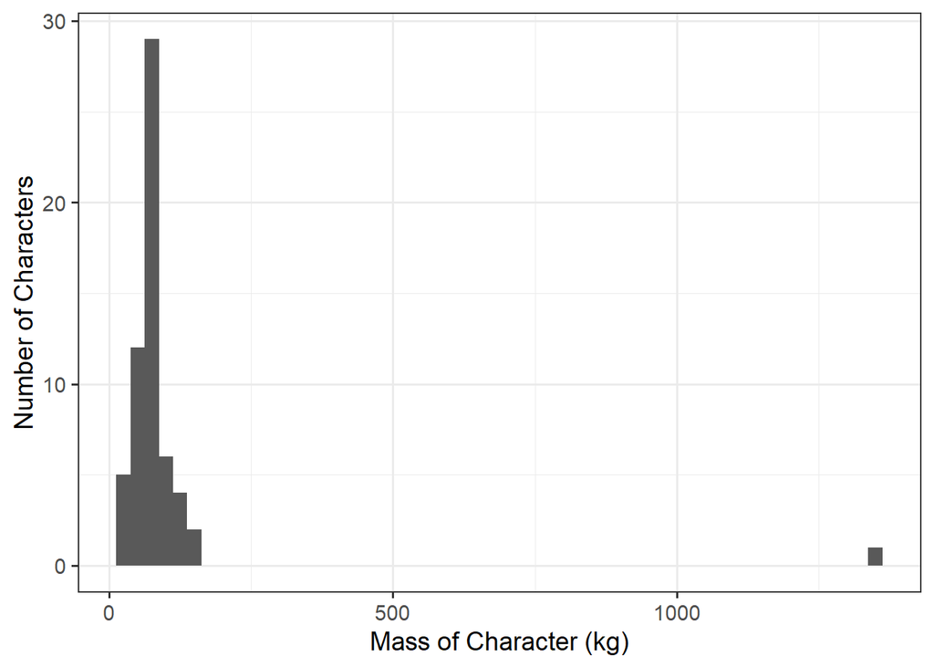

```r
qplot(data = updated_starwars,
      x = mass,
      geom = "histogram",
      binwidth = 25) +
  labs(x = "Mass of Character (kg)",
       y = "Number of Characters")
```

Our plots will primarily be constructed using `qplot()`. Here are a few notes about the arguments to this function:

- `data` tells it which dataset the variables being plotted are found in
- `x` (and/or `y`) determines what goes on the x-axis (or y-axis, as appropriate)
- `geom` this is the work-horse and determines how the data is shown (type of plot to make)
- `binwidth` a special option unique to `geom = "histogram"` which determines how wide to make the bins for the histogram
- `labs()` is added to the `qlot()` function and is used to construct names for the axes (which are descriptive and never the default just accepted).

Construct a box plot of the mass of the characters. Be sure your axes are clearly labeled.

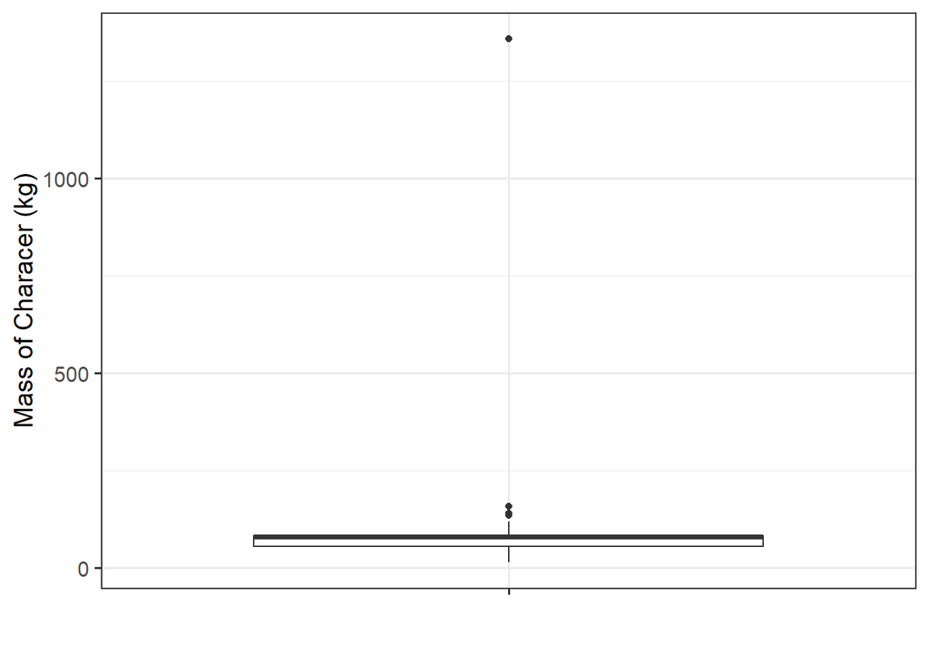

```r
qplot(data = updated_starwars,
      x = "",
      y = mass,
      geom = "boxplot") +
  labs(x = "",
       y = "Mass of Characer (kg)")
```

In the box plot you just constructed, there is a clear outlier. While some people advocate for removing outliers, it is my opinion that we should always examine an outlier to determine whether it represents a mistake or an anomoly (which may be valuable). Based on the context, explain the outlier present in the above box plot.

**SOLUTION**:  
The outlier most likely represents Jabba the Hut. While most characters in the Star Wars universe are human-like, leading to similar masses, Jabba is a rather large alien known for his gluttonous tendencies. The outlier most likely represents this larger character.

## Part IV - Extended Example

For this part, we will be working with the dataset `Salaries` (note R is case senstive; so, the capital “S” matters). This dataset contains salary information from a sample of US professors surveyed during the 2008-2009 academic year. The data contains the following variables:

- `rank`: an indicator of the faculty’s rank (“AssocProf” = Associate Professor, “AsstProf” = Assistant Professor, “Prof” = Full Professor)
- `discipline`: an indicator of the type of department in which the faculty is housed (“A” = theoretical department, “B” = applied department)
- `yrs.since.phd`: years since the individual received their Ph.D.
- `yrs.service`: years of service to the institute
- `sex`: an indicator of the faculty’s sex (“Female” or “Male”)
- `salary`: nine-month salary (US dollars)

In order to access this dataset, you must run the following code:

```r
data("Salaries", package="carData")
```

Using the previous work as a guide, address the prompts that follow.

Construct a histogram of the salaries recorded in the sample. Make a **binwidth of of 5000**. Be sure to appropriately label the x and y axes of the graphic.

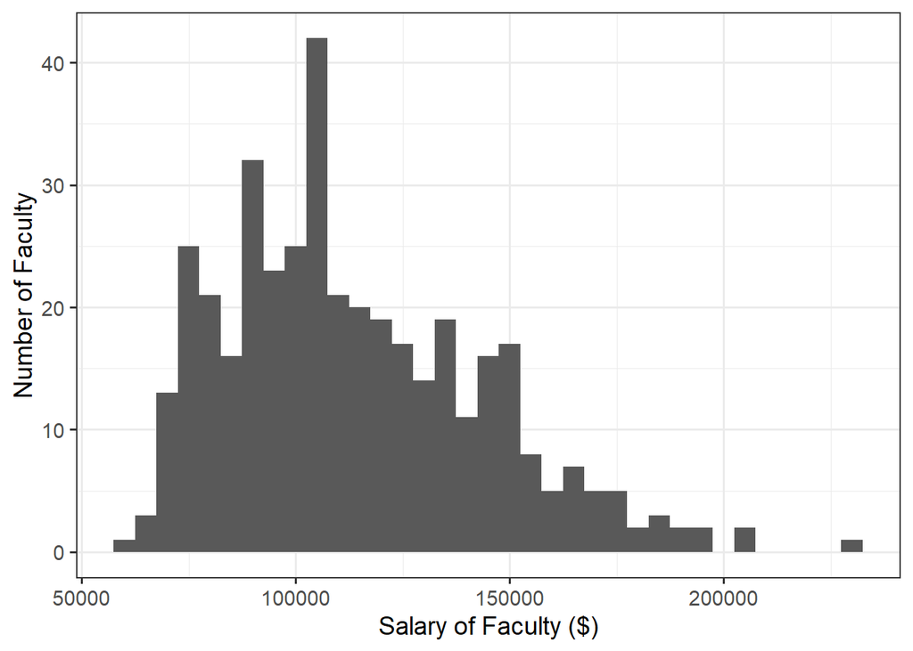

```r
qplot(data = Salaries,
      x = salary,
      geom = "histogram",
      binwidth = 5000) +
  labs(x = "Salary of Faculty ($)",
       y = "Number of Faculty")
```

Construct a density plot of the salaries recorded in the sample. Be sure to appropriately label the x-axis on the graphic.

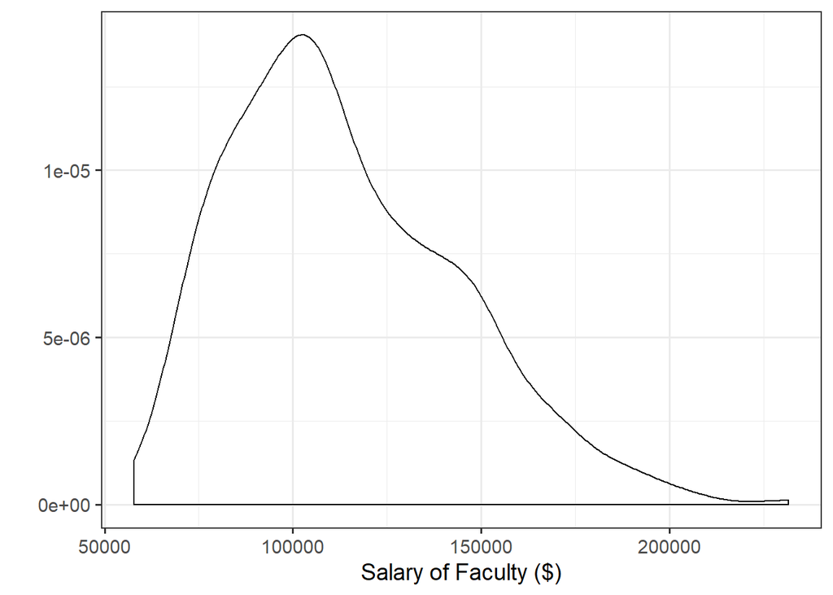

```r
qplot(data = Salaries,
      x = salary,
      geom = "density") +
  labs(x = "Salary of Faculty ($)")
```

Construct a box plot of the salaries recorded in the sample. Be sure to appropriately label the y-axis on the graphic.

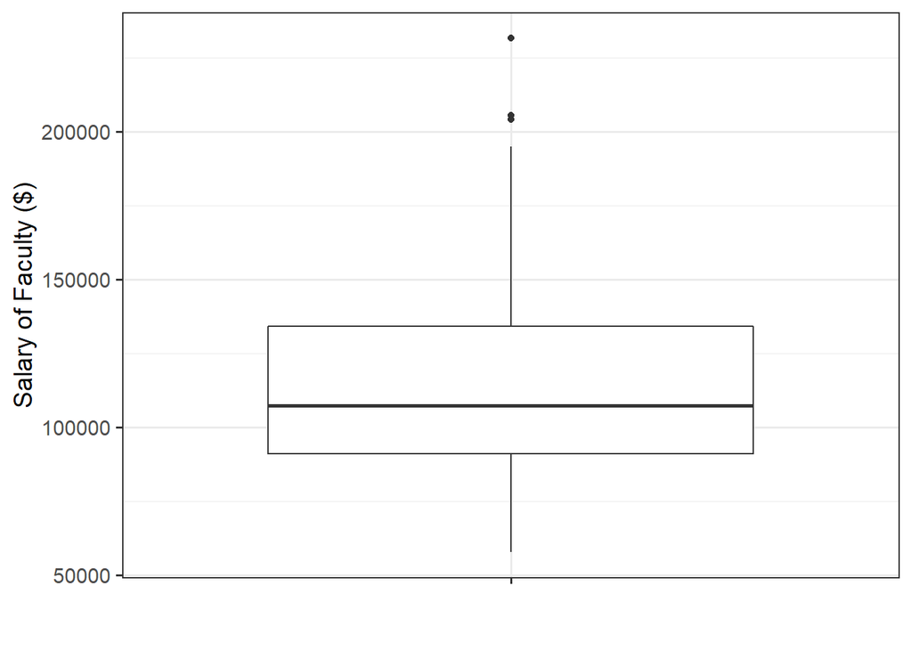

```r
qplot(data = Salaries,
      y = salary,
      x = "",
      geom = "boxplot") +
  labs(y = "Salary of Faculty ($)",
       x = "")
```

Which of the three figures that you constructed above do you feel best summarizes this data? Why?

Based on the figures you constructed, is it common for a faculty member to earn less than $80,000?

The 25% of lowest paid faculty members earn a salary of less than how much? Compute this value exactly and compare it to the boxplot you constructed above. Hint: you need the first quartile.

```r
summarize_variable(salary ~ 1, data = Salaries, Q1)
```

```
  salary
1  91000
```

It is annoying that the data abbreviated the professor ranks. In graphics especially, it would be nice to have this variable store the actual names. Construct a new dataset called `updated_Salaries` which “recodes” the variable `rank` such that

- “AsstProf” becomes “Assistant Prof”
- “AssocProf” becomes “Associate Prof”
- “Prof” becomes “Full Prof”

Note, “recoding” a variable happens within the `mutate()` function.

```r
updated_Salaries = Salaries %>%
  mutate(rank = recode(rank,
                       "AsstProf" = "Assistant Prof",
                       "AssocProf" = "Associate Prof",
                       "Prof" = "Full Prof"))
```

Using the `updated_Salares` dataset you just created, construct a bar chart summarizing the number of faculty within each rank.

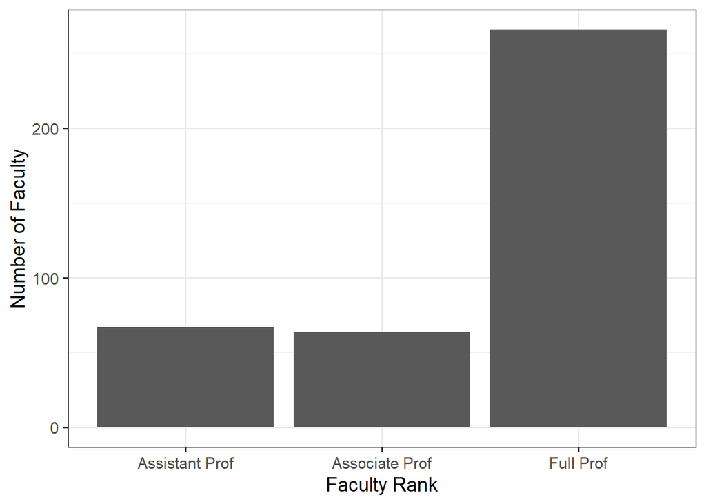

```r
qplot(data = updated_Salaries,
      x = rank,
      geom = "bar") +
  labs(x = "Faculty Rank",
       y = "Number of Faculty")
```